# eda

mao

2021/11/17

# 1.相關係數圖

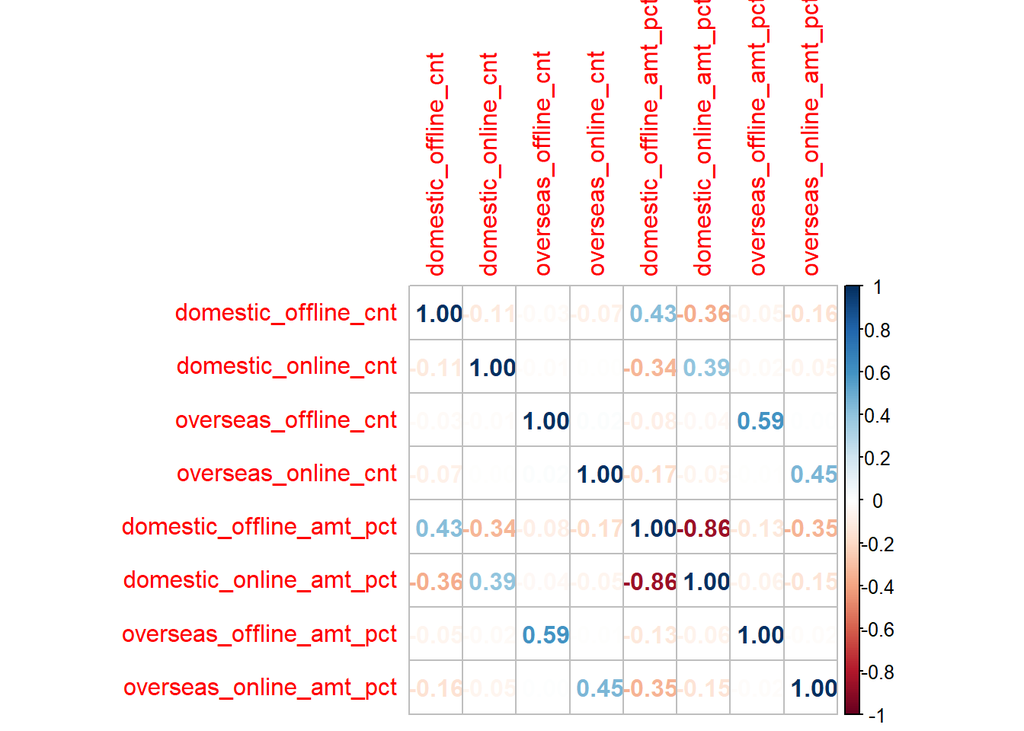

# 2.消費次數

## (1)國內實體通路消費次數

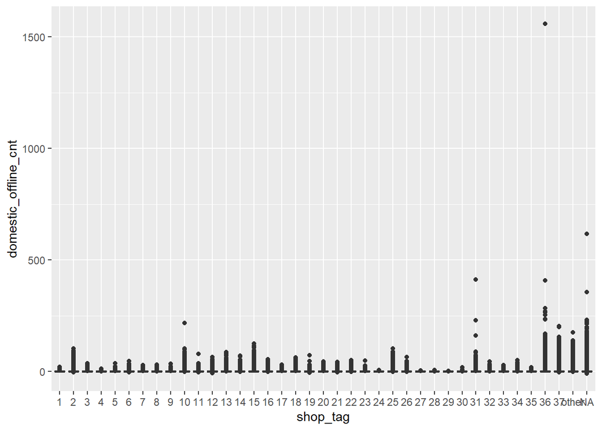

## (2)國內線上通路消費次數

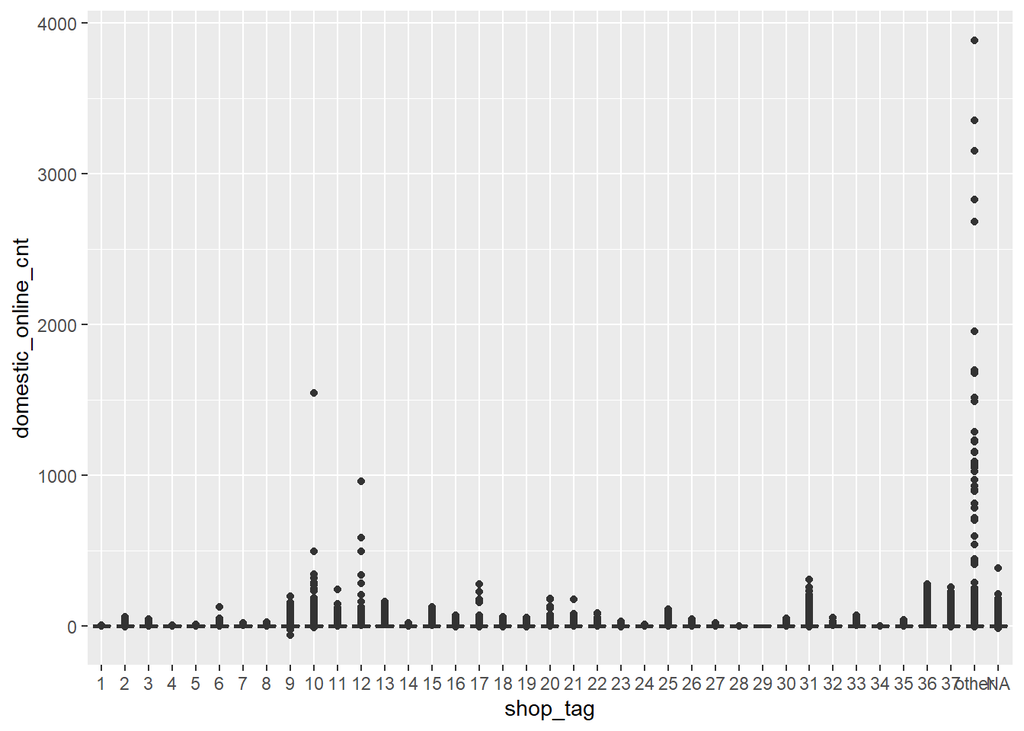

## (3)海外實體通路消費次數

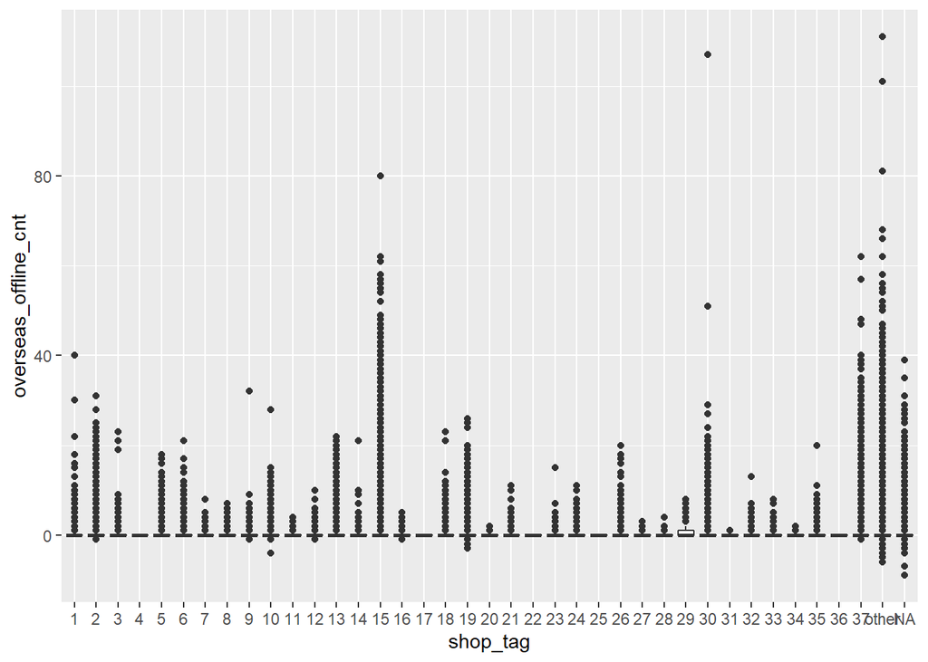

## (4)海外線上通路消費次數

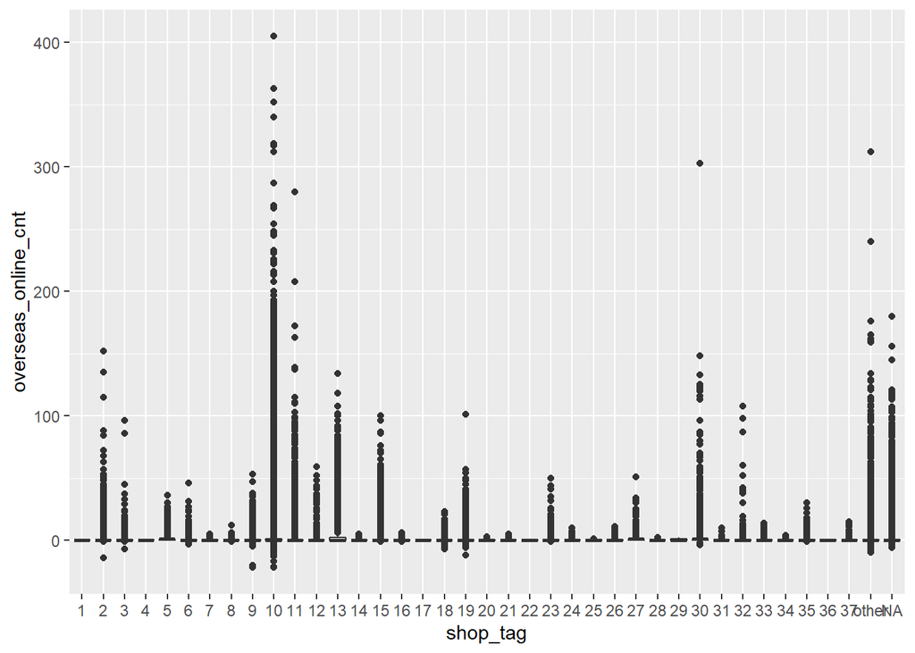

# 3.消費金額占比

## (1)國內實體通路消費金額佔比

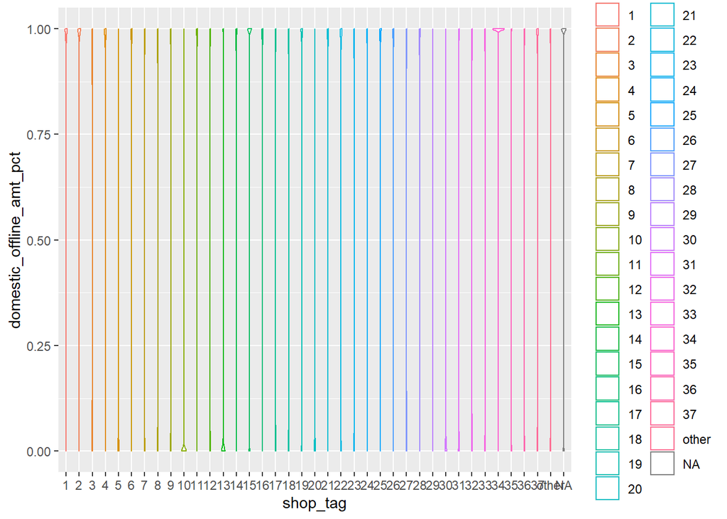

## (2)國內線上通路消費金額佔比

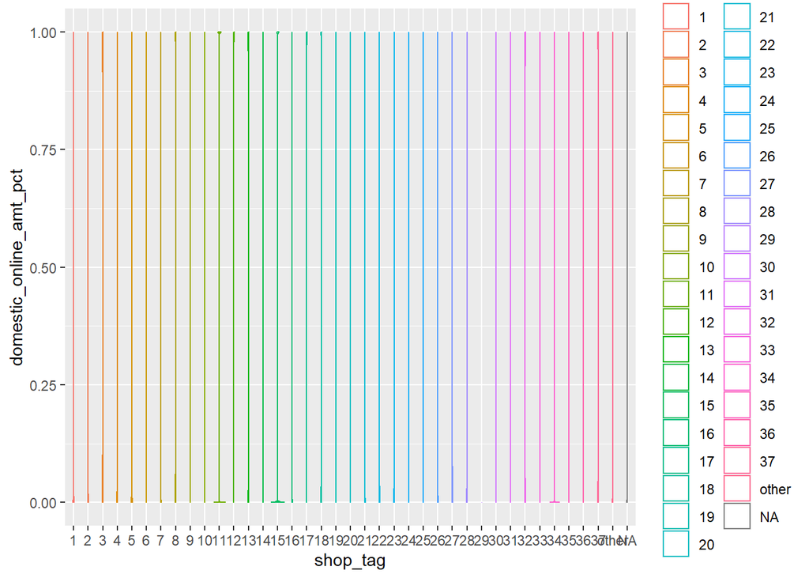

## (3)海外實體通路消費金額佔比

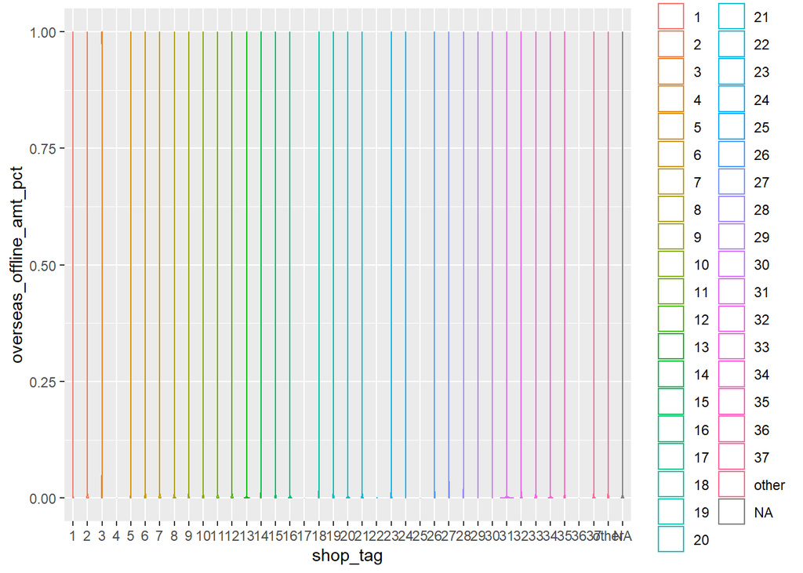

## (4)海外線上通路消費金額佔比

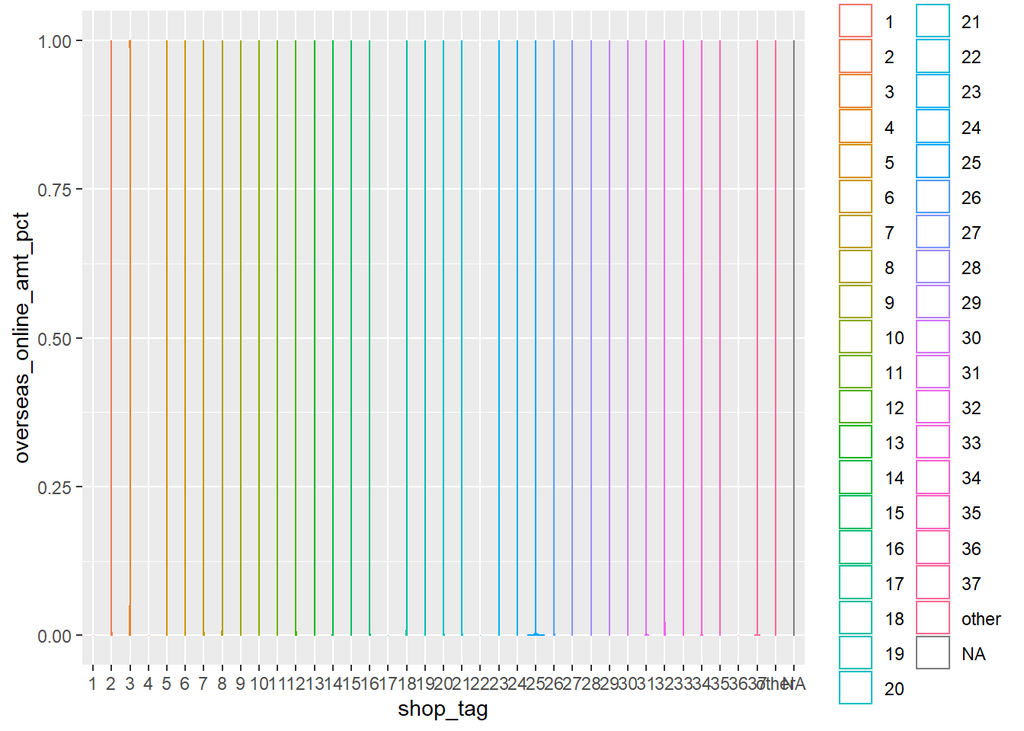

# 4.消費金額占比

## (1)國內實體通路消費金額佔比

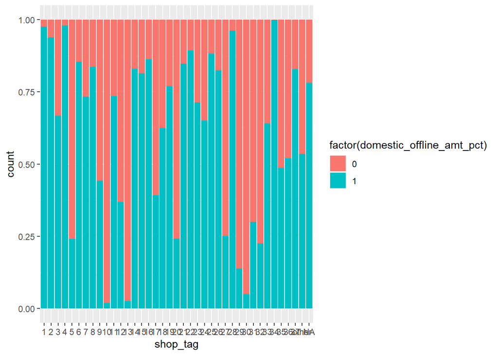

## (2)國內線上通路消費金額佔比

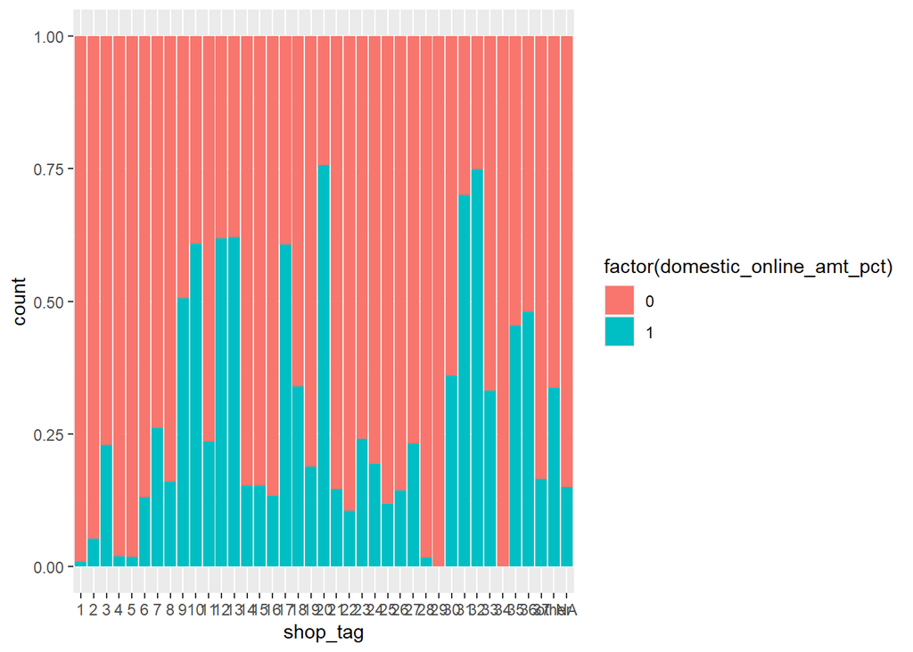

## (3)海外實體通路消費金額佔比

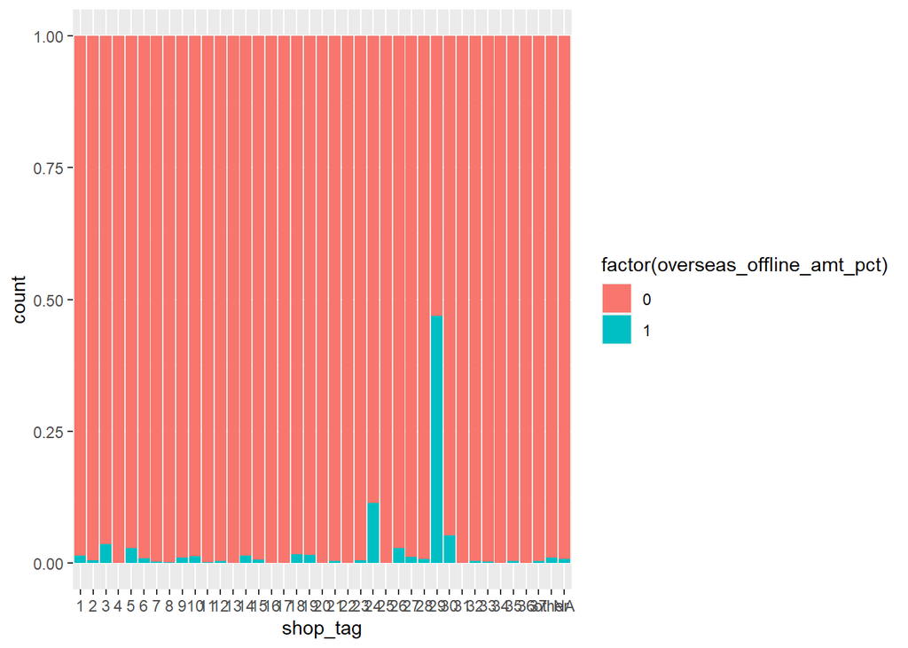

## (4)海外線上通路消費金額佔比

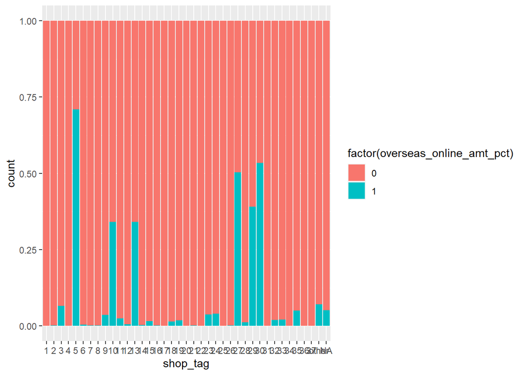